# STAT5003

Week 5: Q & A

Dr. Justin Wishart

2020-09-23

> What is the odds ratio in Logistic Regression? And what does it mean ‘maps the probability from (0,1) to (0, inf)’? The probability isn`t between 0 to 1?

The probability value $0 \le p \le 1$. The odds ratio is the ratio of success to failure.

Odds ratio = $\frac{p}{1 - p}$

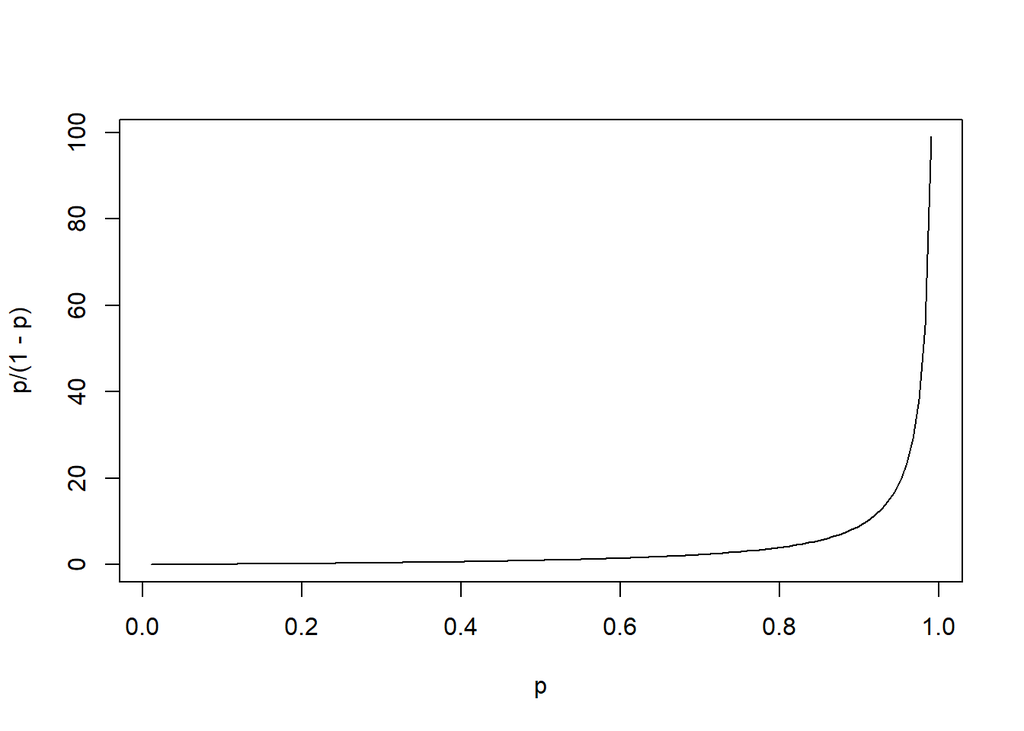

> What is the family in the glm command?
- Generalized linear models have two parts
- Linear predictor $\boldsymbol{\theta}^T \boldsymbol{X}_i = \beta_0 + \beta_1 X_{1i} + \ldots + \beta_p X_{pi}$
- Link and variance functions $\mathbb{E}Y_i = \mu_i$ and $g(\mu_i) = h_i$ and $Var(Y_i) = \phi V(\mu_i)$
- The above doesn’t specify the probaility distribution
  - The family gives that distribution

## Binomial family

- Model the binary data with bernoulli distribution (special case of the binomial)
- $P(Y_i = y| X_1, X_2, \ldots) = \begin{cases} p_i = p(\boldsymbol{X}_i) & \quad \text{if } y = 1\\ 1 - p_i = 1 - p(\boldsymbol{X}_i) & \quad \text{if } y = 0\\\end{cases}$

## Other family choices

- Gamma distribution
- Poisson distribution
- Negative Binomial distribution (not quite a GLM)

> Could you please explain null and residual deviance in details?
- Deviance is a more generalized goodness of fit metric used in GLMs
  - Consider it as a generalization of the Residual Sum of Squares $RSS = \sum_{i = 1}^n (Y_i - \widehat{Y_i})^2$
- It is based off the log likelihood of the data assuming different model setups.
  - Log likelihood $\mathcal L(\boldsymbol{\theta}|Y, \boldsymbol{X})$
- Null model (Choose $\boldsymbol{\theta}^T \boldsymbol{X}_i = \beta_0$)
- Saturated or perfect model has a parameter for each observation
  - $n$ observations $\leadsto n$ parameters
  - Overfit the model to give a perfect fit

## Null vs regular model vs Saturated model

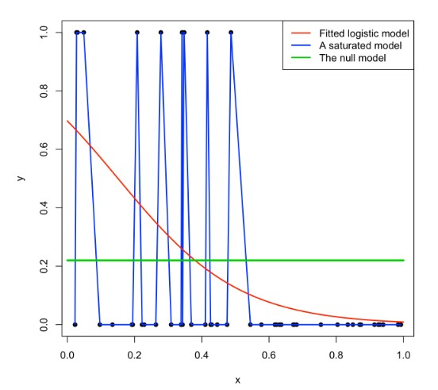

- Taken from [Bookdown.org](https://bookdown.org/egarpor/PM-UC3M/glm-deviance.html)

## Ok so what are the null and residual deviance exactly?

- Goodness of fit measure by looking how much of the likelihood changes
- Null deviance $D_0 = -2(\mathcal L (\beta_0) - \mathcal L_s)$
  - Measures Change in likelihood from perfect fit to probably horrible fit
- Residual deviance $D = -2(\mathcal L(\widehat{\boldsymbol{\theta}}) - \mathcal L_s)$
  - Measures change in likelihood from perfect fit to current model.

## Parametric vs Non-parametric

- Logistic regression has interpretable parameters.
- $\log(p/(1-p)) = \beta_0+ \beta_1 X_1 + \ldots + \beta_p X_p$
- $\frac{p}{1 - p} = \frac{P(Y = 1 | \boldsymbol{X})}{P(Y = 0 | \boldsymbol{X})} = \exp \left( \beta_0+ \beta_1 X_1 + \ldots + \beta_p X_p \right)$
- Consider change of unit increase in $X_1$ between two observations
- $\frac{\frac{P(Y = 1 | X_1 = x + 1)}{P(Y = 0 | X_1 = x + 1)}}{\frac{P(Y = 1 | X_1 = x)}{P(Y = 0 | X_1 = x)}} = \frac{\exp \left( \beta_0+ \beta_1 (x + 1) + \ldots + \beta_p X_p \right)}{\exp \left( \beta_0+ \beta_1 x + \ldots + \beta_p X_p \right)} = e^{\beta_1}$

## Generalize classification to multi-class

> How do you generalize these models to a multiclass problem?

$$\log ( \frac{p}{1 - p}) = \boldsymbol{X} \boldsymbol{\beta} \qquad \text{Binary logit}$$

- Can extend binary models to multi class via the methods in lecture
  - One vs all
  - All pairwise models
- Multi class algorithms also exist.
  - Tree and ensemble methods upcoming
  - Multinomial logit

> “Both Logistic Regression and LDA produce linear boundaries”. The boundary of logistic regression is not a curve?
- The boundary here refers to the decision being made.

> why we can use mean() to calculate the accuracy of classification
- Data types in `R` will be coerced to the appropriate type
  - `x == y` will create a *logical* vector (`TRUE` or `FALSE`) of all the elements where `x` and `y` are the same
  - `mean` wants numeric input and will convert `TRUE` to 1 and `FALSE` to zero.

```r
x <- c(1, 2, 3, 7, 5)
y <- c(1, 2, 3, 4, 5)
x == y
```

```
## [1]  TRUE  TRUE  TRUE FALSE  TRUE
```

```r
mean(x == y)
```

```
## [1] 0.8
```

```r
sum(x == y)/length(x)
```

```
## [1] 0.8
```

> What is the difference between linear regression and the hyperplane in SVM when the problem has 2 dimensions (p=2)?
- Linear regression is attempting to fit the line of best fit through the data
  - $Y_i = \beta_0 + \beta_1 X_1 + \varepsilon$

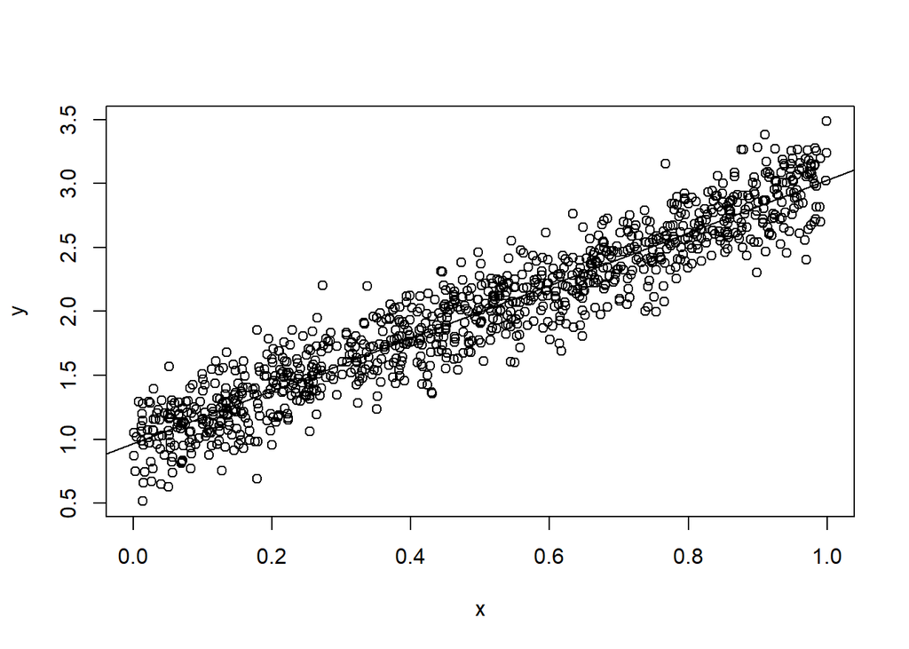

```r
x <- runif(1e3)
y <- 2 * x + 1 + rnorm(1e3, sd = 1/5)
plot(x, y)
abline(lsfit(x, y))
```

- Goal is the model the mean of $Y$ conditional on $X$.
  - Predict $Y$ based on knowledge of $X$

> What is the difference between linear regression and the hyperplane in SVM when the problem has 2 dimensions (p=2)?
- In SVM, the goal is to separate the labelled points into two classes via a linear boundary.

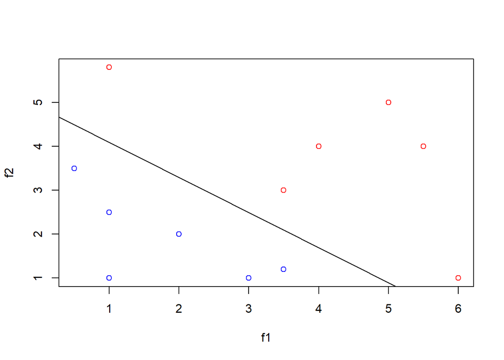

```r
f1 <- c(.5, 1, 1, 2, 3, 3.5,     1, 3.5, 4, 5, 5.5, 6)
f2 <- c(3.5, 1, 2.5, 2, 1, 1.2,  5.8, 3, 4, 5, 4, 1)
cls <- c(rep(1, 6), rep(2, 6))
dat <- cbind(f1, f2)
plot(f1, f2, col = c("blue", "red")[cls])
svm.model <- e1071::svm(dat, y = factor(cls), kernel = "linear", scale = FALSE)
coefs <- coef(svm.model)
abline(a=-coefs[1]/coefs[3], b=-coefs[2]/coefs[3], col = "black", lty = 1)
```

> Support Vector Machines, Which Kernel should I pick? or stick with linear?
- Short answer, depends on the structure of your data.
  - Radial basis is a good naive choice since can adapt to nonlinear problems
  - linear is good for linearly separable data (and its fast), should be preference if model fits well.
- Similar in spirit to the choice of linkage in clustering.
  - Depends on the structure of the data.

## Bayes, LDA vs QDA

- Bayes classification
  - Classify according to the rule $\widehat c = \arg\max_i P(x \in C_i|x) = f(x| x \in C_i) P(x \in C_i)/f(x)$
  - $\widehat c = \arg\max_i f_i(x) \pi_i$
- LDA assumes normal distributed data with means different for each class
  - A common covariance structure to all classes.
- QDA assumes normally distributed data (same as above)
  - Each class can have a different covariance matrix
- Could do naive bayes assume simplifying structure
  - $f_i(\boldsymbol{x}) = \prod_{j = 1}^d f_{ij}(x_i)$

## LDA vs QDA

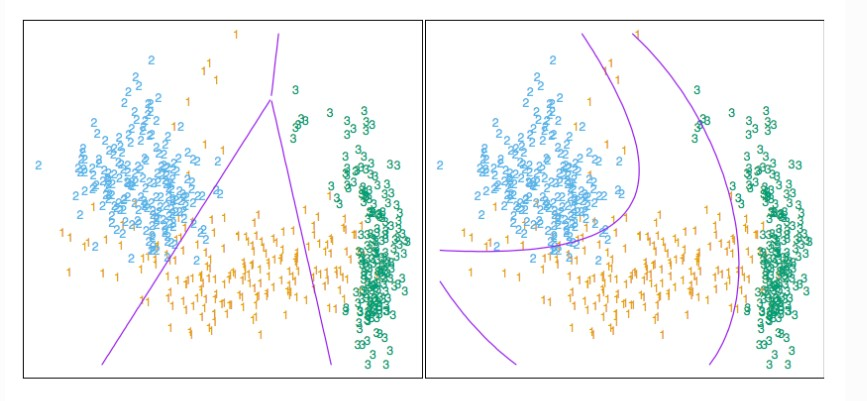

## Fishers Linear Discriminant

- Similar to ANOVA
- Looks at the ratio of between to within variability.
  - $FC = \frac{(\mu_1 - \mu_2)^2}{s_1^2 + s_2^2}$
  - $\mu_i$ are the class means and $s_i^2$ are the class variances.
- Looks for a transformation $w$ that maximizes that ratio
  - $FC_w = \frac{(\mu_{1w} - \mu_{2w})^2}{s_{1w}^2 + s_{2w}^2}$
  - Define $y = \boldsymbol{w}^T \boldsymbol{x} = w_1 x_1 + w_2 x_2 + \ldots w_p x_p$
- See wikipedia, ran out of time to type this…. code below

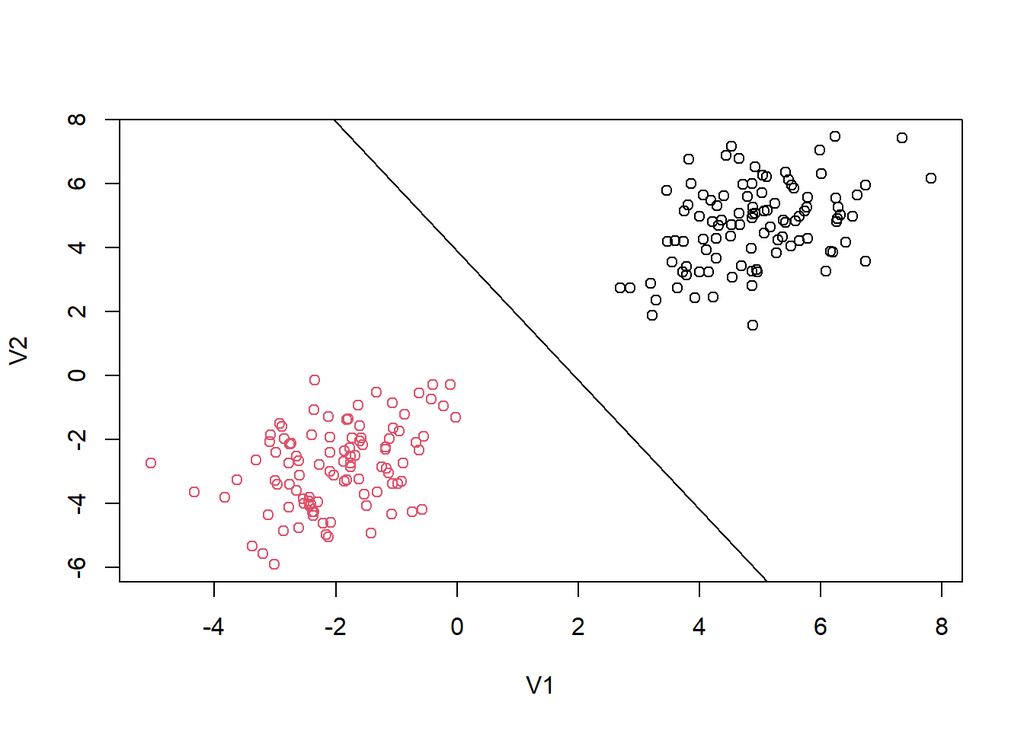

```r
simulated.data <- rbind.data.frame(MASS::mvrnorm(n = 100,
                                                 mu = c(5, 5),
                                                 Sigma = matrix(c(1, 0.5, 0.5, 2), nrow = 2)),
                                   MASS::mvrnorm(n = 100,
                                                 mu = c(-2, -3),
                                                 Sigma = matrix(c(1, 0.5, 0.5, 2), nrow = 2)))
simulated.data[["class"]] <- rep(LETTERS[1:2], each = 100)

split.dat <- split(simulated.data[1:2],
                   simulated.data[["class"]])

means <- lapply(split.dat, colMeans)
mean.diff <- means[[1]] - means[[2]]

covs <- lapply(split.dat, cov)

w <- solve(covs[[1]] + covs[[2]]) %*% matrix(mean.diff, ncol = 1)
c <- t(w) %*% matrix(means[[1]] + means[[2]], ncol = 1)/2
# plot the decision boundaries
plot(simulated.data[1:2], col = as.numeric(factor(simulated.data[["class"]])))
intercept <- c/w[2, 1]
slope <- -w[1, 1]/w[2, 1]
abline(intercept, slope)
```